# Biomechanical features of orthopedic patients

Rajeev Kumar Rajesh

23/08/2020

## Introduction

This project ‘Biomechanical features of orthopedic patients’.In this project each patient is represented in the data set by six biomechanical attributes derived from the shape and orientation of the pelvis and lumbar spine (each one is a column).

i)Pelvic incidence ii)Pelvic tilt iii)lumbar lordosis angle iv)Sacral slope v)Pelvic radius vi)Grade of spondylolisthesis

We use these biomechanical features to classify patients according to their labels.And also find the correlation between above variable.

```r
# Read the csv File
dat <- read.csv("column_2C_weka.csv", stringsAsFactors = F)
head(dat)
```

```
##   pelvic_incidence pelvic_tilt.numeric lumbar_lordosis_angle sacral_slope
## 1         63.02782           22.552586              39.60912     40.47523
## 2         39.05695           10.060991              25.01538     28.99596
## 3         68.83202           22.218482              50.09219     46.61354
## 4         69.29701           24.652878              44.31124     44.64413
## 5         49.71286            9.652075              28.31741     40.06078
## 6         40.25020           13.921907              25.12495     26.32829
##   pelvic_radius degree_spondylolisthesis    class
## 1      98.67292                -0.254400 Abnormal
## 2     114.40543                 4.564259 Abnormal
## 3     105.98514                -3.530317 Abnormal
## 4     101.86850                11.211523 Abnormal
## 5     108.16872                 7.918501 Abnormal
## 6     130.32787                 2.230652 Abnormal
```

```r
dim(dat)
```

```
## [1] 310   7
```

```r
str(dat)
```

```
## 'data.frame':    310 obs. of  7 variables:
##  $ pelvic_incidence        : num  63 39.1 68.8 69.3 49.7 ...
##  $ pelvic_tilt.numeric     : num  22.55 10.06 22.22 24.65 9.65 ...
##  $ lumbar_lordosis_angle   : num  39.6 25 50.1 44.3 28.3 ...
##  $ sacral_slope            : num  40.5 29 46.6 44.6 40.1 ...
##  $ pelvic_radius           : num  98.7 114.4 106 101.9 108.2 ...
##  $ degree_spondylolisthesis: num  -0.254 4.564 -3.53 11.212 7.919 ...
##  $ class                   : chr  "Abnormal" "Abnormal" "Abnormal" "Abnormal" ...
```

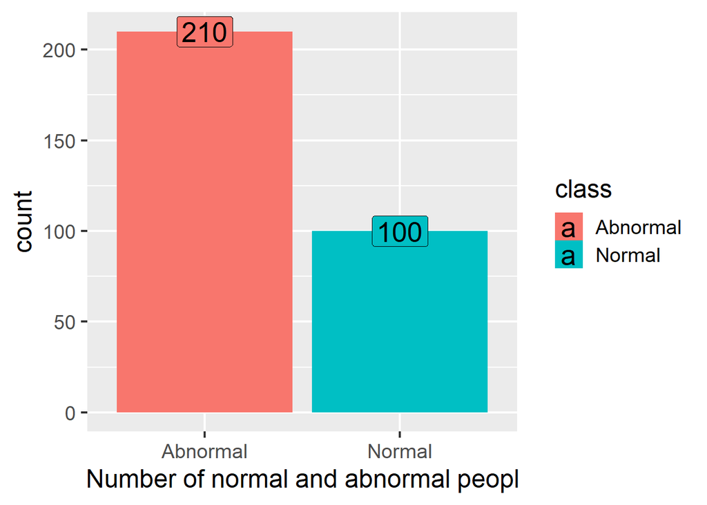

```r
#Total Normal and abnormal people
ggplot(dat,aes(x=class,fill=class))+geom_bar(stat = 'count')+labs(x = 'Number of normal and abnormal peopl') +
  geom_label(stat='count',aes(label=..count..), size=7) +theme_grey(base_size = 18)
```

```r
table(dat$class)
```

```
##
## Abnormal   Normal
##      210      100
```

# Analysis of histogram Of all the explanatory variable

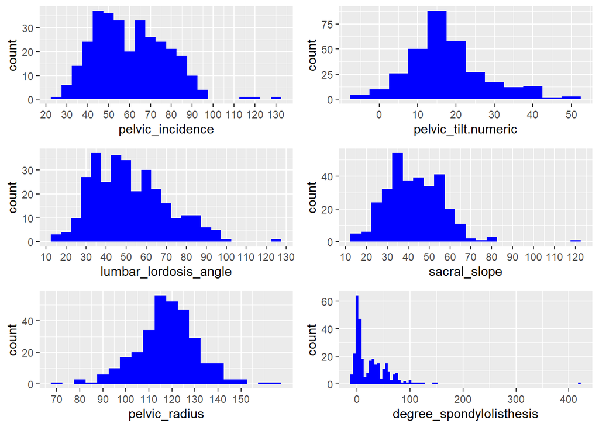

```r
#Histogram explain all the detail of all six variable

H1<-ggplot(dat,aes(x=pelvic_incidence ))+
  geom_histogram(binwidth = 5, fill='blue')+ theme_grey() +
  scale_x_continuous(breaks= seq(0, 150, by=10))
H2<-ggplot(dat,aes(x=pelvic_tilt.numeric ))+
  geom_histogram(binwidth = 5, fill='blue') + theme_grey() +
  scale_x_continuous(breaks= seq(0, 150, by=10))
H3<-ggplot(dat,aes(x=lumbar_lordosis_angle ))+
  geom_histogram(binwidth = 5, fill='blue') + theme_grey() +
  scale_x_continuous(breaks= seq(0, 150, by=10))
H4<-ggplot(dat,aes(x=sacral_slope ))+
  geom_histogram(binwidth = 5, fill='blue') + theme_grey() +
  scale_x_continuous(breaks= seq(0, 150, by=10))
H5<-ggplot(dat,aes(x=pelvic_radius ))+
  geom_histogram(binwidth = 5, fill='blue') + theme_grey() +
  scale_x_continuous(breaks= seq(0, 150, by=10))
H6<-ggplot(dat,aes(x=degree_spondylolisthesis ))+
  geom_histogram(binwidth = 5, fill='blue') + theme_grey()
grid.arrange(H1,H2,H3,H4,H5,H6)
```

```r
set.seed(1, sample.kind = 'Rounding')
```

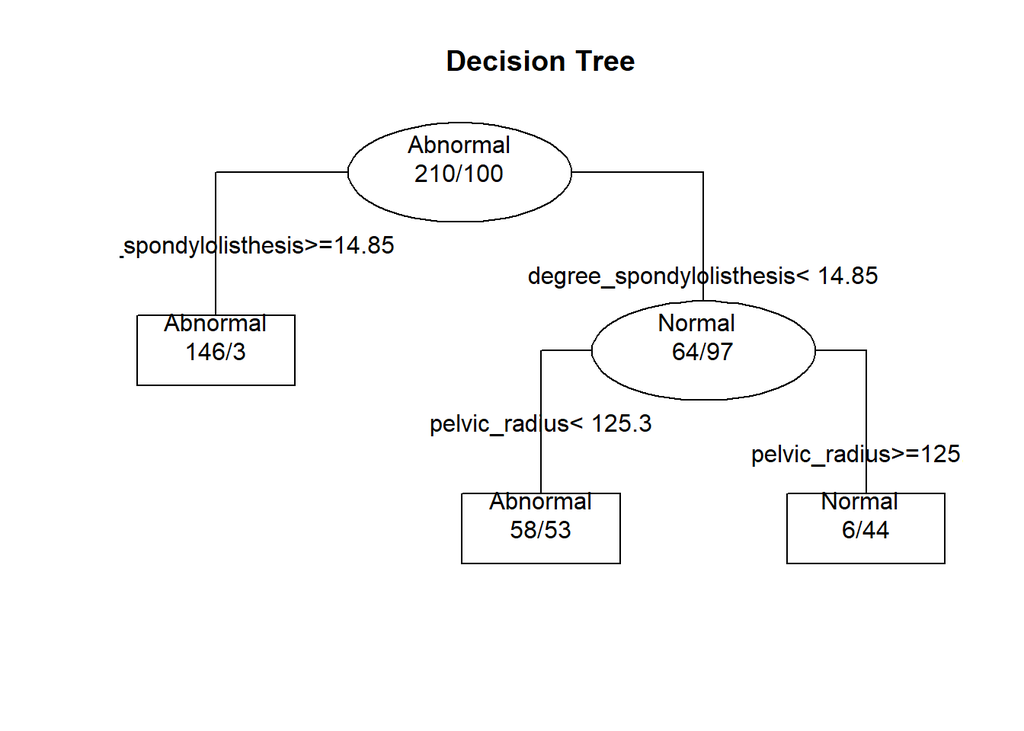

```r
library(rpart)
arbre <- rpart(dat$class~., method="class", minsplit=150, xval=10000, data=dat)
plot(arbre, uniform=TRUE, margin=0.1, main="Decision Tree")
text(arbre, fancy=TRUE, use.n=TRUE, pretty=0, all=TRUE)
```

We find that those with inferior spondylolisthesis at 14.85 are those of patients who are fortunate enough to have normal class,but it should be noted that it is normal that when pelvic_radius is supperieur or equal to 125.

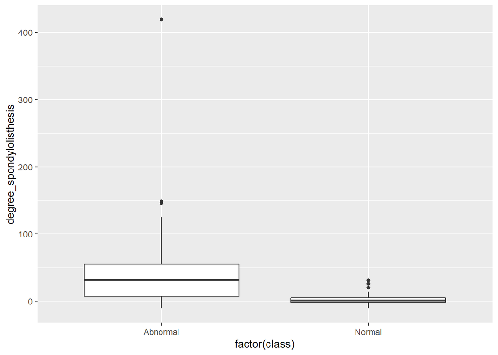

```r
#We can also view it on the boxplot.
ggplot(dat,aes(x=factor(class),y=degree_spondylolisthesis))+geom_boxplot()
```

We can also visualize the density of the set of variables of importance that explains the class of patients.

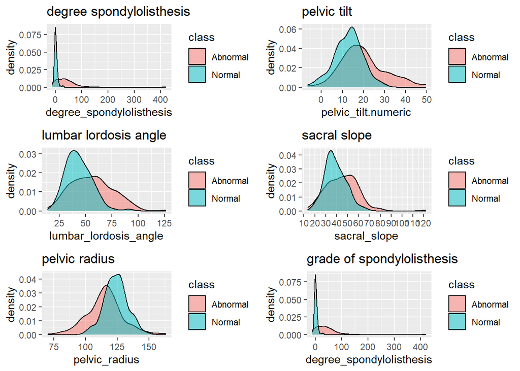

```r
D1<-ggplot(dat,aes(x=degree_spondylolisthesis,fill=class))+
  geom_density(alpha=0.5, aes(fill=factor(class))) +
  labs(title="degree spondylolisthesis")  + theme_grey()
D2<-ggplot(dat,aes(x=pelvic_tilt.numeric,fill=class))+
  geom_density(alpha=0.5, aes(fill=factor(class))) +
  labs(title="pelvic tilt")  + theme_grey()
D3<-ggplot(dat,aes(x=lumbar_lordosis_angle,fill=class))+
  geom_density(alpha=0.5, aes(fill=factor(class))) +
  labs(title="lumbar lordosis angle") + theme_grey()
D4<-ggplot(dat,aes(x=sacral_slope,fill=class))+
  geom_density(alpha=0.5, aes(fill=factor(class))) + labs(title="sacral slope") +
  scale_x_continuous(breaks = scales::pretty_breaks(n = 10)) + theme_grey()
D5<-ggplot(dat,aes(x=pelvic_radius,fill=class))+
  geom_density(alpha=0.5, aes(fill=factor(class))) +
  labs(title="pelvic radius") + theme_grey()
D6<-ggplot(dat,aes(x=degree_spondylolisthesis,fill=class))+
  geom_density(alpha=0.5, aes(fill=factor(class))) +
  labs(title="grade of spondylolisthesis") + theme_grey()
grid.arrange(D1,D2,D3,D4,D5,D6)
```

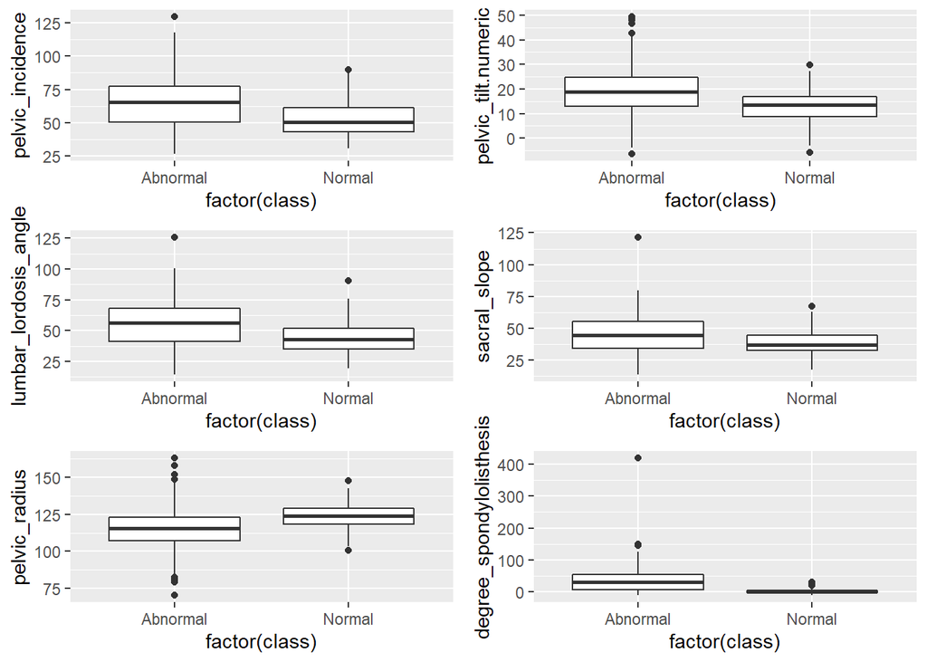

```r
#Below is the boxplot of all variables
B1<-ggplot(dat,aes(x=factor(class),y=pelvic_incidence ))+geom_boxplot()
B2<-ggplot(dat,aes(x=factor(class),y=pelvic_tilt.numeric))+geom_boxplot()
B3<-ggplot(dat,aes(x=factor(class),y=lumbar_lordosis_angle))+geom_boxplot()
B4<-ggplot(dat,aes(x=factor(class),y=sacral_slope))+geom_boxplot()
B5<-ggplot(dat,aes(x=factor(class),y=pelvic_radius))+geom_boxplot()
B6<-ggplot(dat,aes(x=factor(class),y=degree_spondylolisthesis))+geom_boxplot()
grid.arrange(B1,B2,B3,B4,B5,B6)
```

# Correlation between variables

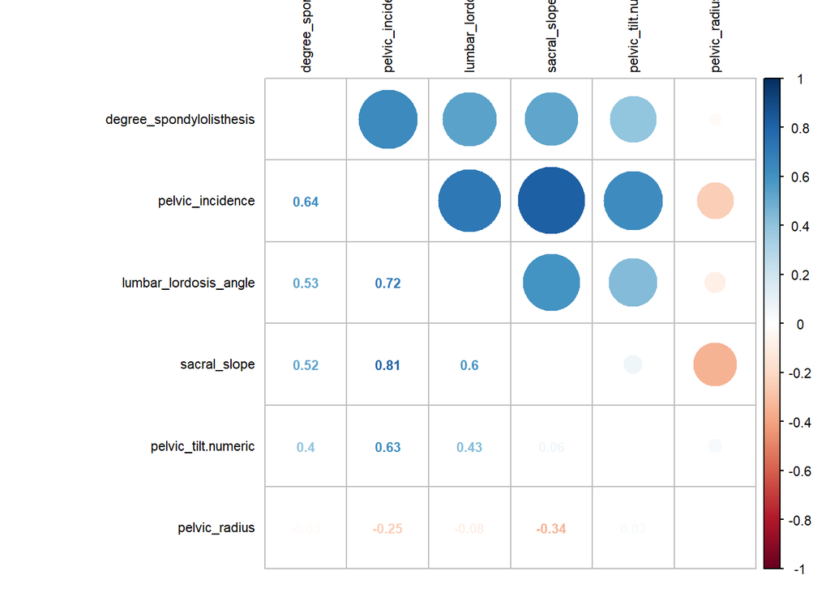

```r
library(corrplot)
numericVars <- which(sapply(dat, is.numeric)) #index vector numeric variables
dat_numVar <- dat[, numericVars]
cor_numVar <- cor(dat_numVar, use="pairwise.complete.obs") #correlations of all numeric variables
#sort on decreasing correlations with degree_spondylolisthesis
cor_sorted <- as.matrix(sort(cor_numVar[,'degree_spondylolisthesis'], decreasing = TRUE))
#select only high corelations
CorHigh <- names(which(apply(cor_sorted, 1, function(x) abs(x)>0)))
cor_numVar <- cor_numVar[CorHigh, CorHigh]
corrplot.mixed(cor_numVar, tl.col="black", tl.pos = "lt", tl.cex = 0.7,cl.cex = .7, number.cex=.7)
```

We notice that,there are 3 numeric variables with a correlation of at least 0.5 with degree_spondylolisthesis,and there is no correlation between pelvic_radius and degree_spondylolisthesis.It also becomes clear the multicollinearity is an issue. For example: the correlation between sacral_slope and pelvic_incidence is very high (0.81), and both have similar (high) correlations with degree_spondylolisthesis. Now let us visualize the correlation of these variables with respect to our target before visualizing that of sacral_slope and pelvic_incidence.

# Now we analyze the relationship between degree spondylolisthesis And rest of the other Variables

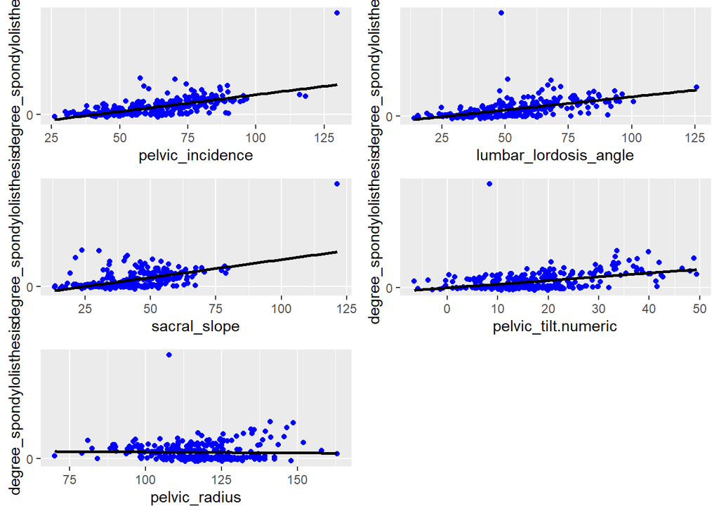

```r
library(gridExtra)
s1<-ggplot(data=dat, aes(x=pelvic_incidence, y=degree_spondylolisthesis))+
  geom_point(col='blue') + geom_smooth(method = "lm", se=FALSE, color="black", aes(group=1)) +
  scale_y_continuous(breaks= seq(0, 800000, by=100000))
s2<-ggplot(data=dat, aes(x=lumbar_lordosis_angle, y=degree_spondylolisthesis))+
  geom_point(col='blue') + geom_smooth(method = "lm", se=FALSE, color="black", aes(group=1)) +
  scale_y_continuous(breaks= seq(0, 800000, by=100000))
s3<-ggplot(data=dat, aes(x=sacral_slope, y=degree_spondylolisthesis))+
  geom_point(col='blue') + geom_smooth(method = "lm", se=FALSE, color="black", aes(group=1)) +
  scale_y_continuous(breaks= seq(0, 800000, by=100000))
s4<-ggplot(data=dat, aes(x=pelvic_tilt.numeric, y=degree_spondylolisthesis))+
  geom_point(col='blue') + geom_smooth(method = "lm", se=FALSE, color="black", aes(group=1)) +
  scale_y_continuous(breaks= seq(0, 800000, by=100000))
s5<-ggplot(data=dat, aes(x=pelvic_radius, y=degree_spondylolisthesis))+
  geom_point(col='blue') + geom_smooth(method = "lm", se=FALSE, color="black", aes(group=1)) +
  scale_y_continuous(breaks= seq(0, 800000, by=100000))
grid.arrange(s1,s2,s3,s4,s5)
```

# Visualize us sacral_slope and pelvic_incidence

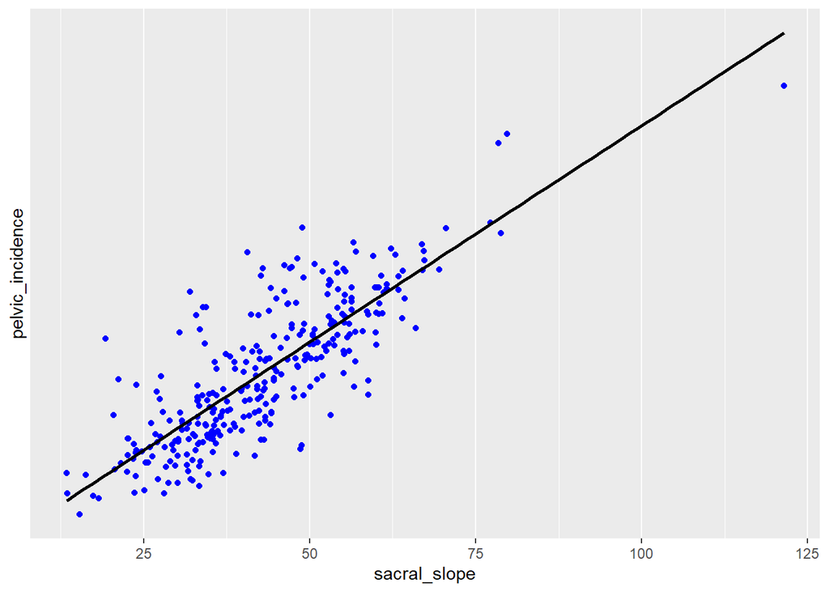

```r
ggplot(data=dat, aes(x=sacral_slope, y=pelvic_incidence))+
  geom_point(col='blue') + geom_smooth(method = "lm", se=FALSE, color="black", aes(group=1)) +
  scale_y_continuous(breaks= seq(0, 800000, by=100000))
```

# Decision tree Analysis

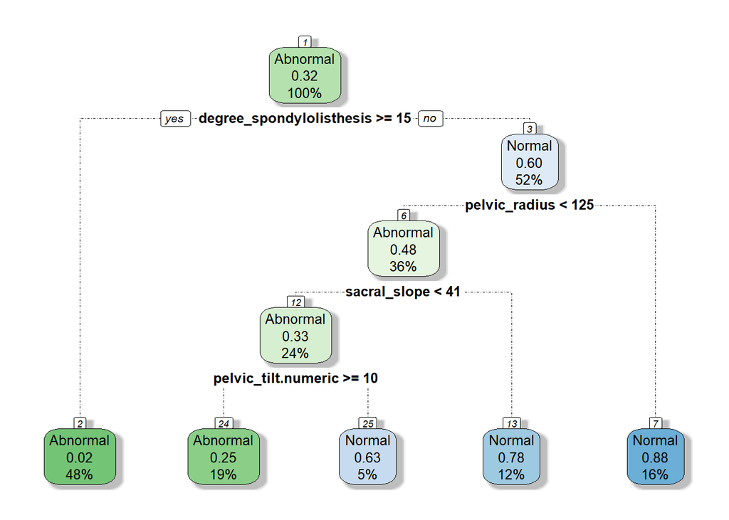

```r
library(rpart.plot)
class.tree <- rpart(dat$class~.,data = dat,control = rpart.control(cp = 0.01))
rpart.plot(class.tree,
           box.palette="GnBu",
           branch.lty=10, shadow.col="gray", nn=TRUE)
```

# Predictions (RandomForest vs Support Vector Machine (SVM) model vs Gradient Boosting Machine (GBM) model)

# RandomForest

```r
caret_matrix <- train(x=dat[,1:6], y=dat[,7], data=dat, method='rf', trControl=trainControl(method="cv", number=5))
caret_matrix
```

```
## Random Forest
##
## 310 samples
##   6 predictor
##   2 classes: 'Abnormal', 'Normal'
##
## No pre-processing
## Resampling: Cross-Validated (5 fold)
## Summary of sample sizes: 248, 248, 248, 248, 248
## Resampling results across tuning parameters:
##
##   mtry  Accuracy   Kappa
##   2     0.8193548  0.5826725
##   4     0.8225806  0.5945959
##   6     0.8225806  0.5996912
##
## Accuracy was used to select the optimal model using the largest value.
## The final value used for the model was mtry = 4.
```

# Support Vector Machine (SVM) model

```r
caret_svm <- train(x=dat[,1:6], y=dat[,7], data=dat, method='svmRadial', trControl=trainControl(method="cv", number=5))
caret_svm
```

```
## Support Vector Machines with Radial Basis Function Kernel
##
## 310 samples
##   6 predictor
##   2 classes: 'Abnormal', 'Normal'
##
## No pre-processing
## Resampling: Cross-Validated (5 fold)
## Summary of sample sizes: 248, 248, 248, 248, 248
## Resampling results across tuning parameters:
##
##   C     Accuracy   Kappa
##   0.25  0.8483871  0.6422330
##   0.50  0.8516129  0.6537262
##   1.00  0.8612903  0.6752598
##
## Tuning parameter 'sigma' was held constant at a value of 0.2651415
## Accuracy was used to select the optimal model using the largest value.
## The final values used for the model were sigma = 0.2651415 and C = 1.
```

# Gradient Boosting Machine (GBM) model

```r
caret_boost <- train(class~pelvic_incidence+pelvic_tilt.numeric+lumbar_lordosis_angle+sacral_slope+
pelvic_radius+
  degree_spondylolisthesis, data=dat, method='gbm', preProcess= c('center', 'scale'), trControl=trainControl(method="cv", number=7), verbose=FALSE)
print(caret_boost)
```

```
## Stochastic Gradient Boosting
##
## 310 samples
##   6 predictor
##   2 classes: 'Abnormal', 'Normal'
##
## Pre-processing: centered (6), scaled (6)
## Resampling: Cross-Validated (7 fold)
## Summary of sample sizes: 266, 266, 266, 265, 266, 265, ...
## Resampling results across tuning parameters:
##
##   interaction.depth  n.trees  Accuracy   Kappa
##   1                   50      0.8161616  0.5751694
##   1                  100      0.8388167  0.6329559
##   1                  150      0.8387446  0.6255215
##   2                   50      0.8292208  0.6131845
##   2                  100      0.8387446  0.6296751
##   2                  150      0.8321789  0.6197502
##   3                   50      0.8613276  0.6823848
##   3                  100      0.8451659  0.6462887
##   3                  150      0.8259019  0.6003576
##
## Tuning parameter 'shrinkage' was held constant at a value of 0.1
##
## Tuning parameter 'n.minobsinnode' was held constant at a value of 10
## Accuracy was used to select the optimal model using the largest value.
## The final values used for the model were n.trees = 50, interaction.depth =
##  3, shrinkage = 0.1 and n.minobsinnode = 10.
```